# Project of Module 5

Dario Godoy

2024-07-01

# In this project

This project corresponds to Module 5 of Developing Data Products Course. This assignment has two parts:

1. Create a Shiny app and deploy it.
2. Prepare a reproducible pitch presentation about the app.

The app include:

1. Two numeric input boxes
2. A prediction model on dataset
3. An output of concentration predicted on inputs with the calculated model

# Use of app

The origin of data is “Pharmacokinetics of Theophylline dataset” (“Theoph”). The Theoph data frame has 132 rows and 5 columns of data from an experiment on the pharmacokinetics of theophylline. The variables are:

- **Subject**: an ordered factor with levels 1, …, 12 identifying the subject on whom the observation was made. The ordering is by increasing maximum concentration of theophylline observed.
- **Wt**: weight of the subject (kg).
- **Dose**: dose of theophylline administered orally to the subject (mg/kg).
- **Time**: time since drug administration when the sample was drawn (hr).
- **conc**: theophylline concentration in the sample (mg/L).

Additional data are in my GitHub Repository.

# Theof dataset

Boeckmann, Sheiner and Beal (1994) report data from a study by Dr. Robert Upton of the kinetics of the anti-asthmatic drug theophylline. Twelve subjects were given oral doses of theophylline then serum concentrations were measured at 11 time points over the next 25 hours.

```
## Classes 'nfnGroupedData', 'nfGroupedData', 'groupedData' and 'data.frame':   132 obs. of  5 variables:
##  $ Subject: Ord.factor w/ 12 levels "6"<"7"<"8"<"11"<..: 11 11 11 11 11 11 11 11 11 11 ...
##  $ Wt     : num  79.6 79.6 79.6 79.6 79.6 79.6 79.6 79.6 79.6 79.6 ...
##  $ Dose   : num  4.02 4.02 4.02 4.02 4.02 4.02 4.02 4.02 4.02 4.02 ...
##  $ Time   : num  0 0.25 0.57 1.12 2.02 ...
##  $ conc   : num  0.74 2.84 6.57 10.5 9.66 8.58 8.36 7.47 6.89 5.94 ...
##  - attr(*, "formula")=Class 'formula'  language conc ~ Time | Subject
##   .. ..- attr(*, ".Environment")=<environment: R_EmptyEnv>
##  - attr(*, "labels")=List of 2
##   ..$ x: chr "Time since drug administration"
##   ..$ y: chr "Theophylline concentration in serum"
##  - attr(*, "units")=List of 2
##   ..$ x: chr "(hr)"
##   ..$ y: chr "(mg/l)"
```

# Plot Theoph dataset

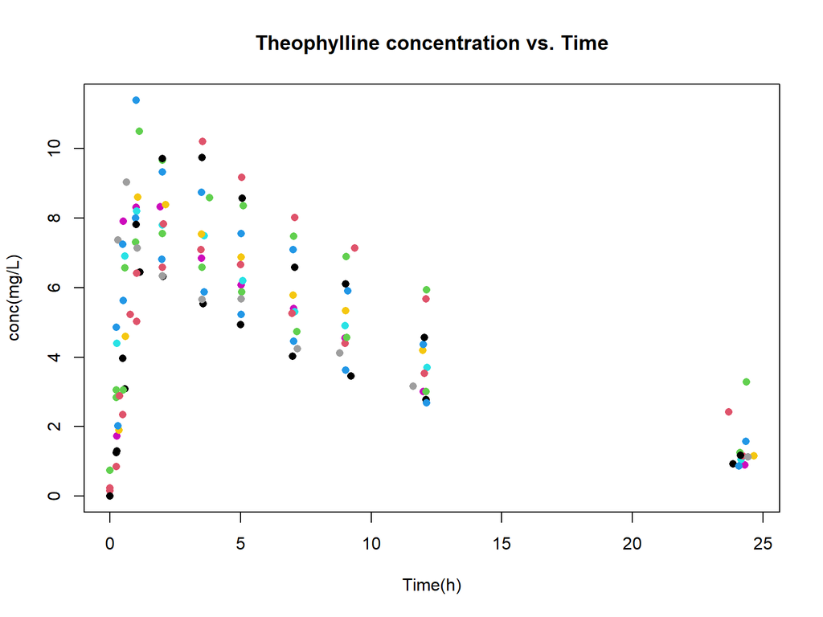